# Statistical Analysis

Cover Wu

2021/2/9

## Introduction

This is a Rmarkdown notebook representing primary results of statistical analysis. First, we will briefly introduce the question to be explored. In the field of urban planning, *urban vitality* is an important concept, firstly brought up by Jane Jacobs. Previous research works have developed several metrics to measure the construct. Specifically in this study, the concept refer to the intensity of human activity in a specific urban area, and is treated as between-subject dummy variable: video with high or low vitality is played. We expect that level of urban vitality can significantly predict the subjective experience, and personality factor (specifically, interpersonal trust score in this study) play a role of moderation, illustrated as below.

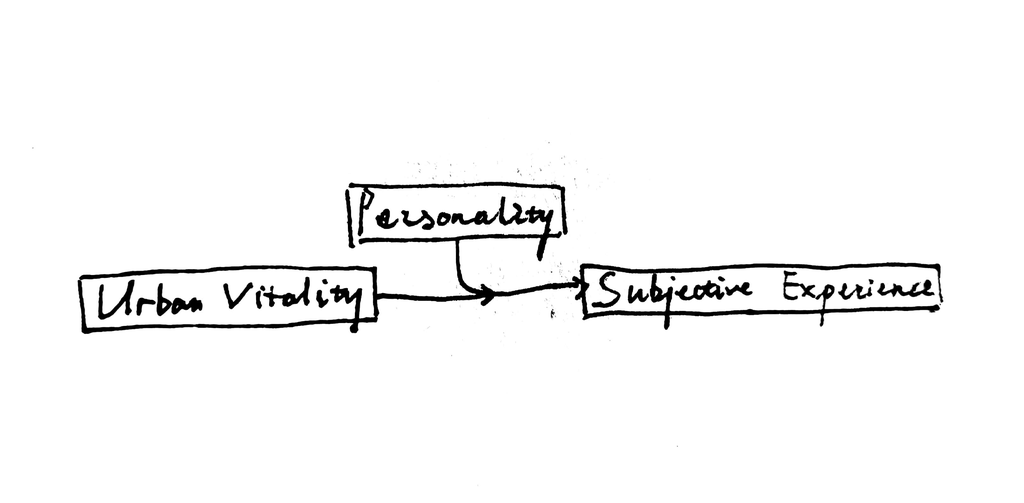

## Exploratory data analysis (EDA)

In this part, exploratory analysis will be performed.

> Descriptive Stat

Firstly, we represent descriptive statistical results. The most important of them are mean and standard deviation. Here, the function **psych::describe()** and **describeBy()** are used to report characteristics of data from both questionnaire and tobii eye-tracker.

```r
# descriptive stat results of personality data.
describe(personality %>% select(Neuroticism:`Interpersonal Trust`))
```

|  | vars | n | mean | sd | median | trimmed | mad | min | max | range | skew | kurtosis | se |
| --- | --- | --- | --- | --- | --- | --- | --- | --- | --- | --- | --- | --- | --- |
| Neuroticism | 1 | 72 | 3.55 | 0.86 | 3.50 | 3.54 | 0.74 | 1.62 | 5.62 | 4.00 | 0.14 | -0.12 | 0.10 |
| Conscientiousness | 2 | 72 | 4.37 | 0.71 | 4.50 | 4.41 | 0.56 | 2.38 | 5.88 | 3.50 | -0.62 | 0.26 | 0.08 |
| Agreeableness | 3 | 72 | 4.47 | 0.58 | 4.50 | 4.49 | 0.56 | 2.88 | 5.38 | 2.50 | -0.37 | -0.44 | 0.07 |
| Openness | 4 | 72 | 4.20 | 0.75 | 4.12 | 4.21 | 0.65 | 1.75 | 5.88 | 4.12 | -0.27 | 0.72 | 0.09 |
| Extraversion | 5 | 72 | 3.56 | 0.84 | 3.50 | 3.56 | 0.93 | 1.25 | 5.25 | 4.00 | -0.08 | -0.14 | 0.10 |
| Interpersonal Trust | 6 | 72 | 2.47 | 0.41 | 2.40 | 2.45 | 0.44 | 1.70 | 3.60 | 1.90 | 0.44 | 0.03 | 0.05 |

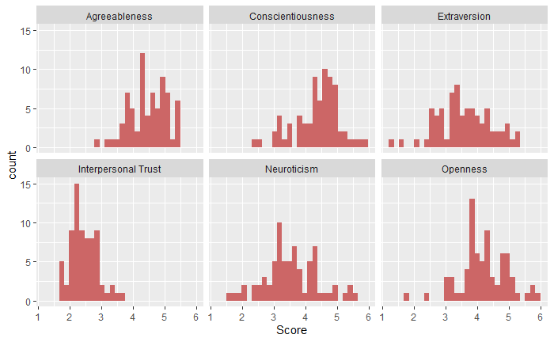

```r
# visualization: data distribution.
ggplot(personality %>% select(Neuroticism:`Interpersonal Trust`) %>% gather(everything(), key = 'Variable', value = 'Score')) +
  geom_histogram(aes(x = Score), fill = "#CC6666") +
  facet_wrap(~ Variable, nrow = 2)
```

```r
# descriptive stat results of visiting experience: note, there's 2 ways to code, in which multiple columns can be analyzed at the same time.
#   method 1: old coding style, yield an intermediate variable "for_descriptive_stat"
for_descriptive_stat <- left_join(visit_scale_score, personality[c("Key", "Level of Vitality")], by = "Key")
describeBy(x = select(for_descriptive_stat, Satisfaction:Compatibility),
  group = list(for_descriptive_stat$Scenario, for_descriptive_stat$`Level of Vitality`))
```

```
 Descriptive statistics by group
: Business District
: High
```

|  | vars | n | mean | sd | median | trimmed | mad | min | max | range | skew | kurtosis | se |
| --- | --- | --- | --- | --- | --- | --- | --- | --- | --- | --- | --- | --- | --- |
| Satisfaction | 1 | 36 | 4.03 | 1.13 | 4.00 | 4.03 | 0.74 | 2.0 | 6.0 | 4.0 | 0.06 | -0.44 | 0.19 |
| Escape | 2 | 36 | 3.41 | 1.21 | 3.10 | 3.35 | 1.04 | 1.4 | 6.0 | 4.6 | 0.58 | -0.54 | 0.20 |
| Fascination | 3 | 36 | 3.77 | 1.19 | 3.80 | 3.79 | 0.89 | 1.4 | 6.4 | 5.0 | -0.09 | -0.52 | 0.20 |
| Coherence | 4 | 36 | 3.67 | 0.87 | 3.75 | 3.62 | 0.74 | 1.5 | 6.0 | 4.5 | 0.41 | 0.87 | 0.15 |
| Compatibility | 5 | 36 | 3.11 | 0.98 | 3.00 | 3.07 | 0.89 | 1.2 | 5.4 | 4.2 | 0.50 | -0.03 | 0.16 |

```
---------------------------------------------------------------------------------
: Metro Station
: High
```

|  | vars | n | mean | sd | median | trimmed | mad | min | max | range | skew | kurtosis | se |
| --- | --- | --- | --- | --- | --- | --- | --- | --- | --- | --- | --- | --- | --- |
| Satisfaction | 1 | 35 | 2.69 | 1.21 | 2.00 | 2.62 | 1.48 | 1 | 6.00 | 5.00 | 0.60 | -0.13 | 0.20 |
| Escape | 2 | 35 | 2.29 | 1.11 | 2.00 | 2.17 | 1.19 | 1 | 5.80 | 4.80 | 1.11 | 1.17 | 0.19 |
| Fascination | 3 | 35 | 2.62 | 1.09 | 2.60 | 2.54 | 0.89 | 1 | 5.20 | 4.20 | 0.46 | -0.10 | 0.18 |
| Coherence | 4 | 35 | 5.06 | 1.03 | 5.25 | 5.07 | 1.48 | 3 | 6.75 | 3.75 | -0.05 | -1.30 | 0.17 |
| Compatibility | 5 | 35 | 2.39 | 0.93 | 2.40 | 2.34 | 0.89 | 1 | 4.60 | 3.60 | 0.39 | -0.51 | 0.16 |

```
---------------------------------------------------------------------------------
: Night Traffic
: High
```

|  | vars | n | mean | sd | median | trimmed | mad | min | max | range | skew | kurtosis | se |
| --- | --- | --- | --- | --- | --- | --- | --- | --- | --- | --- | --- | --- | --- |
| Satisfaction | 1 | 36 | 4.06 | 1.22 | 4.00 | 4.03 | 1.48 | 2.00 | 7.00 | 5.0 | 0.27 | -0.58 | 0.20 |
| Escape | 2 | 36 | 3.91 | 1.35 | 4.00 | 3.92 | 1.78 | 1.20 | 6.20 | 5.0 | -0.04 | -1.08 | 0.23 |
| Fascination | 3 | 36 | 3.60 | 1.07 | 3.50 | 3.58 | 0.74 | 1.60 | 6.60 | 5.0 | 0.38 | 0.17 | 0.18 |
| Coherence | 4 | 36 | 4.21 | 1.10 | 4.25 | 4.22 | 1.11 | 1.75 | 6.25 | 4.5 | -0.16 | -0.62 | 0.18 |
| Compatibility | 5 | 36 | 3.14 | 1.09 | 3.00 | 3.08 | 1.19 | 1.60 | 5.80 | 4.2 | 0.61 | -0.62 | 0.18 |

```
---------------------------------------------------------------------------------
: Pedestrian Zone
: High
```

|  | vars | n | mean | sd | median | trimmed | mad | min | max | range | skew | kurtosis | se |
| --- | --- | --- | --- | --- | --- | --- | --- | --- | --- | --- | --- | --- | --- |
| Satisfaction | 1 | 36 | 5.33 | 1.20 | 5.00 | 5.47 | 1.48 | 1.0 | 7.0 | 6.0 | -1.42 | 3.11 | 0.20 |
| Escape | 2 | 36 | 4.87 | 1.27 | 5.00 | 4.97 | 0.89 | 1.2 | 7.0 | 5.8 | -0.81 | 0.50 | 0.21 |
| Fascination | 3 | 36 | 5.47 | 0.94 | 5.60 | 5.49 | 0.89 | 3.2 | 7.0 | 3.8 | -0.22 | -0.67 | 0.16 |
| Coherence | 4 | 36 | 4.35 | 0.92 | 4.38 | 4.35 | 0.93 | 2.5 | 6.5 | 4.0 | 0.02 | -0.35 | 0.15 |
| Compatibility | 5 | 36 | 4.12 | 1.08 | 4.20 | 4.15 | 1.04 | 1.2 | 6.4 | 5.2 | -0.31 | 0.05 | 0.18 |

```
---------------------------------------------------------------------------------
: Business District
: Low
```

|  | vars | n | mean | sd | median | trimmed | mad | min | max | range | skew | kurtosis | se |
| --- | --- | --- | --- | --- | --- | --- | --- | --- | --- | --- | --- | --- | --- |
| Satisfaction | 1 | 36 | 4.53 | 1.21 | 5.0 | 4.53 | 1.48 | 2.0 | 7.0 | 5.0 | -0.11 | -0.96 | 0.20 |
| Escape | 2 | 36 | 4.07 | 1.26 | 4.0 | 4.08 | 1.04 | 1.4 | 7.0 | 5.6 | 0.00 | -0.34 | 0.21 |
| Fascination | 3 | 36 | 4.19 | 1.14 | 4.2 | 4.14 | 1.33 | 2.2 | 7.0 | 4.8 | 0.37 | -0.54 | 0.19 |
| Coherence | 4 | 36 | 3.13 | 0.86 | 3.0 | 3.20 | 1.11 | 1.0 | 4.5 | 3.5 | -0.58 | -0.25 | 0.14 |
| Compatibility | 5 | 36 | 3.51 | 1.09 | 3.4 | 3.41 | 0.89 | 2.0 | 6.8 | 4.8 | 1.02 | 0.89 | 0.18 |

```
---------------------------------------------------------------------------------
: Metro Station
: Low
```

|  | vars | n | mean | sd | median | trimmed | mad | min | max | range | skew | kurtosis | se |
| --- | --- | --- | --- | --- | --- | --- | --- | --- | --- | --- | --- | --- | --- |
| Satisfaction | 1 | 36 | 3.64 | 1.20 | 4.0 | 3.60 | 1.48 | 2.0 | 6.0 | 4.0 | 0.12 | -1.04 | 0.20 |
| Escape | 2 | 36 | 3.06 | 1.15 | 2.9 | 2.93 | 1.04 | 1.6 | 7.0 | 5.4 | 1.31 | 1.80 | 0.19 |
| Fascination | 3 | 36 | 3.17 | 1.13 | 3.2 | 3.09 | 1.04 | 1.2 | 5.6 | 4.4 | 0.49 | -0.55 | 0.19 |
| Coherence | 4 | 36 | 3.99 | 1.09 | 4.0 | 3.97 | 1.11 | 2.0 | 6.5 | 4.5 | 0.22 | -0.62 | 0.18 |
| Compatibility | 5 | 36 | 2.87 | 0.83 | 2.8 | 2.82 | 0.74 | 1.4 | 4.8 | 3.4 | 0.49 | -0.40 | 0.14 |

```
---------------------------------------------------------------------------------
: Night Traffic
: Low
```

|  | vars | n | mean | sd | median | trimmed | mad | min | max | range | skew | kurtosis | se |
| --- | --- | --- | --- | --- | --- | --- | --- | --- | --- | --- | --- | --- | --- |
| Satisfaction | 1 | 36 | 3.83 | 1.48 | 4.0 | 3.80 | 1.48 | 1.0 | 7.0 | 6.0 | 0.28 | -0.85 | 0.25 |
| Escape | 2 | 36 | 3.89 | 1.50 | 3.8 | 3.86 | 1.93 | 1.4 | 6.8 | 5.4 | 0.12 | -1.16 | 0.25 |
| Fascination | 3 | 36 | 3.33 | 1.09 | 3.2 | 3.29 | 1.19 | 1.4 | 5.6 | 4.2 | 0.36 | -0.78 | 0.18 |
| Coherence | 4 | 36 | 4.12 | 1.24 | 4.0 | 4.08 | 1.30 | 2.0 | 7.0 | 5.0 | 0.30 | -0.56 | 0.21 |
| Compatibility | 5 | 36 | 3.03 | 0.99 | 3.0 | 2.95 | 1.04 | 1.4 | 5.6 | 4.2 | 0.67 | -0.27 | 0.16 |

```
---------------------------------------------------------------------------------
: Pedestrian Zone
: Low
```

|  | vars | n | mean | sd | median | trimmed | mad | min | max | range | skew | kurtosis | se |
| --- | --- | --- | --- | --- | --- | --- | --- | --- | --- | --- | --- | --- | --- |
| Satisfaction | 1 | 36 | 5.39 | 0.90 | 6.00 | 5.43 | 1.48 | 3.00 | 7.0 | 4.00 | -0.58 | -0.19 | 0.15 |
| Escape | 2 | 36 | 4.99 | 0.92 | 5.00 | 5.03 | 0.89 | 3.00 | 7.0 | 4.00 | -0.29 | -0.36 | 0.15 |
| Fascination | 3 | 36 | 5.49 | 0.81 | 5.50 | 5.53 | 0.74 | 3.60 | 6.8 | 3.20 | -0.39 | -0.58 | 0.13 |
| Coherence | 4 | 36 | 4.18 | 0.71 | 4.12 | 4.20 | 0.93 | 2.25 | 5.5 | 3.25 | -0.26 | -0.21 | 0.12 |
| Compatibility | 5 | 36 | 4.17 | 0.75 | 4.20 | 4.18 | 0.89 | 2.60 | 5.8 | 3.20 | -0.07 | -0.77 | 0.13 |

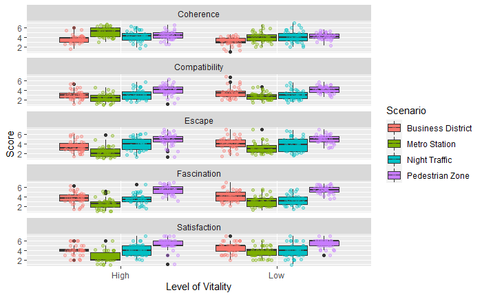

```r
#   method 2: pipe style.
# left_join(visit_scale_score, personality[c("Key", "Level of Vitality")], by = "Key") %>%
#   {describeBy(x = select(., Satisfaction:Compatibility),
#     group = list(.$Scenario, .$`Level of Vitality`))}

# data visualization:
ggplot(for_descriptive_stat %>% gather(Satisfaction:Compatibility, key = 'Variable', value = 'Score'),
       aes(x = `Level of Vitality`, y = Score)) +
  geom_boxplot(aes(fill = Scenario), position = position_dodge(0.8)) +
  geom_point(aes(color = Scenario), position = position_jitterdodge(dodge.width = 0.8, jitter.height = 0.06), alpha = 0.35) +
  facet_wrap(~ Variable, nrow = 5)
```

```r
NA
NA
```

Please note that for “method 2” above, i.e. the latter code style, **{} is necessary**. By using it, the pipe symbol will plug the results before *only into several location* (where “.” appear), *rather than the first argument*.

Eye-tracking metrics are also analyzed, see codes below.

```r
# descriptive analysis
for_descriptive_stat <- eye_data %>% select(Key:`Level of Vitality`, Average_duration_of_whole_fixations, Average_peak_velocity_of_saccades, Average_amplitude_of_saccades, Average_pupil_size, Total_amplitude_of_saccades:Saccade_frequency, Vitality_attention, Vitality_attention_standardized)
describeBy(x = select(for_descriptive_stat, -(Key:`Level of Vitality`)),
  group = list(for_descriptive_stat$Scenario, for_descriptive_stat$`Level of Vitality`))
```

```
 Descriptive statistics by group
: Business District
: Low
```

|  | vars | n | mean | sd | median | trimmed | mad | min | max | range | skew | kurtosis | se |
| --- | --- | --- | --- | --- | --- | --- | --- | --- | --- | --- | --- | --- | --- |
| Average_duration_of_whole_fixations | 1 | 36 | 338.47 | 80.25 | 324.00 | 335.80 | 76.35 | 193.00 | 523.00 | 330.00 | 0.36 | -0.61 | 13.38 |
| Average_peak_velocity_of_saccades | 2 | 36 | 202.10 | 43.09 | 200.94 | 203.06 | 42.42 | 101.46 | 277.11 | 175.65 | -0.19 | -0.72 | 7.18 |
| Average_amplitude_of_saccades | 3 | 36 | 5.76 | 1.25 | 5.78 | 5.79 | 1.42 | 2.82 | 8.35 | 5.53 | -0.16 | -0.61 | 0.21 |
| Average_pupil_size | 4 | 36 | 3.13 | 0.43 | 3.04 | 3.10 | 0.42 | 2.46 | 4.17 | 1.71 | 0.72 | -0.36 | 0.07 |
| Total_amplitude_of_saccades | 5 | 36 | 1443.00 | 581.04 | 1405.49 | 1450.97 | 706.67 | 84.53 | 2497.51 | 2412.98 | -0.08 | -0.66 | 96.84 |
| Fixation_frequency | 6 | 36 | 2.04 | 0.51 | 2.06 | 2.05 | 0.49 | 0.53 | 3.20 | 2.67 | -0.37 | 0.63 | 0.09 |
| Duration_proportion_of_fixations | 7 | 36 | 0.68 | 0.19 | 0.75 | 0.71 | 0.11 | 0.11 | 0.89 | 0.78 | -1.33 | 1.12 | 0.03 |
| Saccade_frequency | 8 | 36 | 1.63 | 0.53 | 1.69 | 1.66 | 0.55 | 0.20 | 2.64 | 2.44 | -0.47 | 0.02 | 0.09 |
| Vitality_attention | 9 | 36 | 0.08 | 0.04 | 0.07 | 0.08 | 0.04 | 0.01 | 0.18 | 0.17 | 0.51 | -0.37 | 0.01 |
| Vitality_attention_standardized | 10 | 36 | 3.45 | 1.76 | 3.14 | 3.39 | 1.66 | 0.37 | 7.77 | 7.40 | 0.51 | -0.37 | 0.29 |

```
---------------------------------------------------------------------------------
: Metro Station
: Low
```

|  | vars | n | mean | sd | median | trimmed | mad | min | max | range | skew | kurtosis | se |
| --- | --- | --- | --- | --- | --- | --- | --- | --- | --- | --- | --- | --- | --- |
| Average_duration_of_whole_fixations | 1 | 36 | 419.81 | 141.37 | 405.50 | 407.20 | 83.77 | 171.00 | 1015.00 | 844.00 | 1.95 | 6.58 | 23.56 |
| Average_peak_velocity_of_saccades | 2 | 36 | 185.48 | 37.53 | 191.22 | 186.34 | 28.79 | 78.96 | 268.61 | 189.65 | -0.43 | 0.45 | 6.25 |
| Average_amplitude_of_saccades | 3 | 36 | 5.42 | 1.28 | 5.56 | 5.48 | 1.22 | 1.59 | 7.76 | 6.17 | -0.54 | 0.47 | 0.21 |
| Average_pupil_size | 4 | 36 | 3.38 | 0.51 | 3.28 | 3.35 | 0.47 | 2.45 | 4.67 | 2.22 | 0.61 | -0.42 | 0.09 |
| Total_amplitude_of_saccades | 5 | 36 | 1189.42 | 465.85 | 1205.10 | 1198.28 | 532.39 | 55.80 | 2122.01 | 2066.21 | -0.18 | -0.41 | 77.64 |
| Fixation_frequency | 6 | 36 | 1.80 | 0.44 | 1.82 | 1.81 | 0.37 | 0.76 | 2.66 | 1.89 | -0.26 | -0.17 | 0.07 |
| Duration_proportion_of_fixations | 7 | 36 | 0.73 | 0.17 | 0.77 | 0.75 | 0.12 | 0.14 | 0.90 | 0.76 | -1.49 | 1.89 | 0.03 |
| Saccade_frequency | 8 | 36 | 1.43 | 0.48 | 1.49 | 1.44 | 0.47 | 0.23 | 2.60 | 2.37 | -0.16 | 0.04 | 0.08 |
| Vitality_attention | 9 | 36 | 0.17 | 0.08 | 0.18 | 0.17 | 0.07 | 0.02 | 0.39 | 0.36 | 0.48 | 0.53 | 0.01 |
| Vitality_attention_standardized | 10 | 36 | 8.98 | 4.00 | 9.37 | 8.78 | 3.58 | 1.29 | 20.43 | 19.15 | 0.48 | 0.53 | 0.67 |

```
---------------------------------------------------------------------------------
: Night Traffic
: Low
```

|  | vars | n | mean | sd | median | trimmed | mad | min | max | range | skew | kurtosis | se |
| --- | --- | --- | --- | --- | --- | --- | --- | --- | --- | --- | --- | --- | --- |
| Average_duration_of_whole_fixations | 1 | 36 | 376.44 | 95.92 | 355.50 | 375.13 | 80.06 | 111.00 | 593.00 | 482.00 | 0.06 | 0.46 | 15.99 |
| Average_peak_velocity_of_saccades | 2 | 36 | 200.18 | 43.15 | 203.50 | 201.34 | 42.22 | 85.66 | 277.70 | 192.04 | -0.30 | -0.36 | 7.19 |
| Average_amplitude_of_saccades | 3 | 36 | 5.57 | 1.49 | 5.42 | 5.60 | 1.46 | 0.93 | 8.82 | 7.89 | -0.38 | 0.93 | 0.25 |
| Average_pupil_size | 4 | 36 | 3.43 | 0.57 | 3.23 | 3.39 | 0.50 | 2.45 | 4.92 | 2.47 | 0.65 | -0.30 | 0.09 |
| Total_amplitude_of_saccades | 5 | 36 | 1247.36 | 524.68 | 1210.88 | 1247.81 | 524.19 | 9.31 | 2200.93 | 2191.62 | 0.06 | -0.50 | 87.45 |
| Fixation_frequency | 6 | 36 | 1.86 | 0.45 | 1.94 | 1.88 | 0.45 | 0.43 | 2.58 | 2.14 | -0.76 | 0.75 | 0.07 |
| Duration_proportion_of_fixations | 7 | 36 | 0.70 | 0.19 | 0.76 | 0.72 | 0.13 | 0.05 | 0.90 | 0.85 | -1.47 | 2.09 | 0.03 |
| Saccade_frequency | 8 | 36 | 1.45 | 0.50 | 1.45 | 1.46 | 0.58 | 0.07 | 2.28 | 2.22 | -0.36 | -0.14 | 0.08 |
| Vitality_attention | 9 | 36 | 0.26 | 0.06 | 0.25 | 0.26 | 0.06 | 0.07 | 0.41 | 0.34 | -0.12 | 0.93 | 0.01 |
| Vitality_attention_standardized | 10 | 36 | 2.38 | 0.58 | 2.33 | 2.37 | 0.52 | 0.64 | 3.78 | 3.13 | -0.12 | 0.93 | 0.10 |

```
---------------------------------------------------------------------------------
: Pedestrian Zone
: Low
```

|  | vars | n | mean | sd | median | trimmed | mad | min | max | range | skew | kurtosis | se |
| --- | --- | --- | --- | --- | --- | --- | --- | --- | --- | --- | --- | --- | --- |
| Average_duration_of_whole_fixations | 1 | 36 | 332.31 | 70.76 | 325.50 | 325.60 | 43.00 | 219.00 | 616.00 | 397.00 | 1.72 | 4.99 | 11.79 |
| Average_peak_velocity_of_saccades | 2 | 36 | 192.86 | 40.49 | 191.14 | 191.25 | 39.43 | 107.88 | 301.41 | 193.53 | 0.39 | 0.26 | 6.75 |
| Average_amplitude_of_saccades | 3 | 36 | 5.56 | 1.23 | 5.70 | 5.52 | 0.93 | 2.95 | 8.89 | 5.94 | 0.31 | 0.32 | 0.21 |
| Average_pupil_size | 4 | 36 | 3.09 | 0.41 | 3.00 | 3.07 | 0.44 | 2.39 | 3.95 | 1.55 | 0.47 | -0.73 | 0.07 |
| Total_amplitude_of_saccades | 5 | 36 | 1489.08 | 556.71 | 1424.89 | 1504.72 | 637.27 | 103.13 | 2485.53 | 2382.40 | -0.20 | -0.62 | 92.78 |
| Fixation_frequency | 6 | 36 | 2.19 | 0.52 | 2.27 | 2.22 | 0.40 | 0.59 | 3.13 | 2.55 | -0.89 | 0.82 | 0.09 |
| Duration_proportion_of_fixations | 7 | 36 | 0.72 | 0.17 | 0.75 | 0.74 | 0.11 | 0.14 | 0.90 | 0.76 | -1.68 | 2.62 | 0.03 |
| Saccade_frequency | 8 | 36 | 1.77 | 0.56 | 1.84 | 1.79 | 0.63 | 0.23 | 2.64 | 2.41 | -0.47 | -0.24 | 0.09 |
| Vitality_attention | 9 | 36 | 0.06 | 0.03 | 0.05 | 0.06 | 0.03 | 0.00 | 0.14 | 0.14 | 0.60 | -0.67 | 0.01 |
| Vitality_attention_standardized | 10 | 36 | 5.88 | 3.52 | 4.99 | 5.66 | 3.34 | 0.43 | 14.55 | 14.11 | 0.60 | -0.67 | 0.59 |

```
---------------------------------------------------------------------------------
: Business District
: High
```

|  | vars | n | mean | sd | median | trimmed | mad | min | max | range | skew | kurtosis | se |
| --- | --- | --- | --- | --- | --- | --- | --- | --- | --- | --- | --- | --- | --- |
| Average_duration_of_whole_fixations | 1 | 36 | 365.94 | 86.15 | 360.50 | 356.23 | 53.37 | 222.00 | 675.00 | 453.00 | 1.46 | 3.19 | 14.36 |
| Average_peak_velocity_of_saccades | 2 | 36 | 194.75 | 34.35 | 196.26 | 192.66 | 42.09 | 135.00 | 306.40 | 171.40 | 0.81 | 1.09 | 5.72 |
| Average_amplitude_of_saccades | 3 | 36 | 5.54 | 1.18 | 5.46 | 5.45 | 0.91 | 3.21 | 9.70 | 6.49 | 1.08 | 2.58 | 0.20 |
| Average_pupil_size | 4 | 36 | 3.17 | 0.44 | 3.18 | 3.16 | 0.33 | 2.32 | 4.56 | 2.25 | 0.41 | 1.19 | 0.07 |
| Total_amplitude_of_saccades | 5 | 36 | 1391.03 | 542.66 | 1347.97 | 1391.96 | 392.88 | 35.36 | 3066.67 | 3031.31 | 0.18 | 1.90 | 90.44 |
| Fixation_frequency | 6 | 36 | 1.95 | 0.55 | 2.01 | 2.00 | 0.32 | 0.13 | 2.93 | 2.80 | -1.42 | 3.04 | 0.09 |
| Duration_proportion_of_fixations | 7 | 36 | 0.71 | 0.19 | 0.74 | 0.74 | 0.14 | 0.03 | 0.92 | 0.89 | -2.12 | 4.88 | 0.03 |
| Saccade_frequency | 8 | 36 | 1.63 | 0.51 | 1.65 | 1.67 | 0.42 | 0.07 | 2.49 | 2.41 | -1.05 | 1.99 | 0.08 |
| Vitality_attention | 9 | 36 | 0.39 | 0.13 | 0.38 | 0.39 | 0.13 | 0.14 | 0.63 | 0.49 | 0.08 | -0.85 | 0.02 |
| Vitality_attention_standardized | 10 | 36 | 4.74 | 1.56 | 4.63 | 4.74 | 1.54 | 1.70 | 7.68 | 5.98 | 0.08 | -0.85 | 0.26 |

```
---------------------------------------------------------------------------------
: Metro Station
: High
```

|  | vars | n | mean | sd | median | trimmed | mad | min | max | range | skew | kurtosis | se |
| --- | --- | --- | --- | --- | --- | --- | --- | --- | --- | --- | --- | --- | --- |
| Average_duration_of_whole_fixations | 1 | 36 | 415.94 | 102.94 | 407.50 | 408.27 | 113.42 | 269.00 | 701.00 | 432.00 | 0.66 | -0.16 | 17.16 |
| Average_peak_velocity_of_saccades | 2 | 36 | 199.52 | 41.19 | 196.56 | 197.10 | 34.48 | 119.56 | 329.67 | 210.11 | 0.81 | 1.25 | 6.87 |
| Average_amplitude_of_saccades | 3 | 36 | 5.58 | 1.41 | 5.36 | 5.51 | 1.03 | 2.34 | 9.00 | 6.66 | 0.44 | 0.17 | 0.24 |
| Average_pupil_size | 4 | 36 | 3.39 | 0.48 | 3.34 | 3.38 | 0.40 | 2.52 | 4.81 | 2.30 | 0.45 | 0.50 | 0.08 |
| Total_amplitude_of_saccades | 5 | 36 | 1184.41 | 577.55 | 1152.64 | 1147.28 | 380.66 | 7.89 | 2970.49 | 2962.60 | 0.89 | 1.72 | 96.26 |
| Fixation_frequency | 6 | 36 | 1.73 | 0.54 | 1.73 | 1.75 | 0.41 | 0.03 | 2.82 | 2.79 | -0.76 | 1.75 | 0.09 |
| Duration_proportion_of_fixations | 7 | 36 | 0.70 | 0.19 | 0.74 | 0.73 | 0.14 | 0.01 | 0.89 | 0.89 | -2.01 | 4.41 | 0.03 |
| Saccade_frequency | 8 | 36 | 1.40 | 0.51 | 1.44 | 1.41 | 0.49 | 0.01 | 2.42 | 2.41 | -0.34 | 0.33 | 0.09 |
| Vitality_attention | 9 | 36 | 0.58 | 0.10 | 0.58 | 0.58 | 0.09 | 0.34 | 0.77 | 0.43 | -0.16 | -0.51 | 0.02 |
| Vitality_attention_standardized | 10 | 36 | 2.86 | 0.52 | 2.86 | 2.88 | 0.45 | 1.70 | 3.83 | 2.13 | -0.16 | -0.51 | 0.09 |

```
---------------------------------------------------------------------------------
: Night Traffic
: High
```

|  | vars | n | mean | sd | median | trimmed | mad | min | max | range | skew | kurtosis | se |
| --- | --- | --- | --- | --- | --- | --- | --- | --- | --- | --- | --- | --- | --- |
| Average_duration_of_whole_fixations | 1 | 36 | 426.39 | 117.82 | 401.00 | 418.30 | 88.96 | 244.00 | 701.00 | 457.00 | 0.72 | -0.50 | 19.64 |
| Average_peak_velocity_of_saccades | 2 | 36 | 192.51 | 32.35 | 191.38 | 191.67 | 29.77 | 131.74 | 283.09 | 151.35 | 0.30 | 0.18 | 5.39 |
| Average_amplitude_of_saccades | 3 | 36 | 5.31 | 1.12 | 5.34 | 5.24 | 1.09 | 3.48 | 8.65 | 5.17 | 0.56 | 0.45 | 0.19 |
| Average_pupil_size | 4 | 36 | 3.40 | 0.52 | 3.46 | 3.40 | 0.49 | 2.26 | 4.58 | 2.32 | -0.08 | -0.31 | 0.09 |
| Total_amplitude_of_saccades | 5 | 36 | 1164.30 | 442.81 | 1202.12 | 1158.39 | 404.86 | 133.93 | 2154.19 | 2020.26 | 0.08 | 0.24 | 73.80 |
| Fixation_frequency | 6 | 36 | 1.80 | 0.49 | 1.90 | 1.83 | 0.36 | 0.41 | 2.78 | 2.37 | -0.63 | 0.52 | 0.08 |
| Duration_proportion_of_fixations | 7 | 36 | 0.74 | 0.16 | 0.78 | 0.77 | 0.11 | 0.12 | 0.89 | 0.77 | -2.23 | 5.47 | 0.03 |
| Saccade_frequency | 8 | 36 | 1.44 | 0.45 | 1.44 | 1.44 | 0.31 | 0.24 | 2.45 | 2.21 | -0.20 | 0.70 | 0.07 |
| Vitality_attention | 9 | 36 | 0.24 | 0.05 | 0.25 | 0.24 | 0.07 | 0.15 | 0.37 | 0.22 | 0.19 | -0.63 | 0.01 |
| Vitality_attention_standardized | 10 | 36 | 2.03 | 0.44 | 2.07 | 2.02 | 0.54 | 1.23 | 3.06 | 1.83 | 0.19 | -0.63 | 0.07 |

```
---------------------------------------------------------------------------------
: Pedestrian Zone
: High
```

|  | vars | n | mean | sd | median | trimmed | mad | min | max | range | skew | kurtosis | se |
| --- | --- | --- | --- | --- | --- | --- | --- | --- | --- | --- | --- | --- | --- |
| Average_duration_of_whole_fixations | 1 | 36 | 339.31 | 73.61 | 316.00 | 334.13 | 63.01 | 222.00 | 596.00 | 374.00 | 1.10 | 1.91 | 12.27 |
| Average_peak_velocity_of_saccades | 2 | 36 | 202.92 | 32.88 | 197.26 | 202.88 | 30.75 | 139.07 | 265.43 | 126.36 | 0.05 | -0.71 | 5.48 |
| Average_amplitude_of_saccades | 3 | 36 | 5.67 | 1.09 | 5.78 | 5.69 | 1.12 | 2.77 | 8.12 | 5.35 | -0.16 | 0.15 | 0.18 |
| Average_pupil_size | 4 | 36 | 3.16 | 0.45 | 3.19 | 3.16 | 0.43 | 2.26 | 4.51 | 2.26 | 0.29 | 0.74 | 0.08 |
| Total_amplitude_of_saccades | 5 | 36 | 1596.36 | 577.58 | 1591.76 | 1598.88 | 416.69 | 77.57 | 3297.65 | 3220.08 | 0.02 | 1.76 | 96.26 |
| Fixation_frequency | 6 | 36 | 2.20 | 0.58 | 2.22 | 2.25 | 0.45 | 0.28 | 3.16 | 2.88 | -1.29 | 2.56 | 0.10 |
| Duration_proportion_of_fixations | 7 | 36 | 0.73 | 0.17 | 0.76 | 0.76 | 0.12 | 0.06 | 0.89 | 0.83 | -2.28 | 5.63 | 0.03 |
| Saccade_frequency | 8 | 36 | 1.84 | 0.56 | 1.84 | 1.87 | 0.33 | 0.19 | 2.92 | 2.73 | -0.73 | 1.54 | 0.09 |
| Vitality_attention | 9 | 36 | 0.34 | 0.12 | 0.34 | 0.34 | 0.14 | 0.11 | 0.58 | 0.47 | 0.07 | -0.79 | 0.02 |
| Vitality_attention_standardized | 10 | 36 | 2.93 | 0.99 | 2.93 | 2.90 | 1.16 | 0.91 | 4.93 | 4.02 | 0.07 | -0.79 | 0.17 |

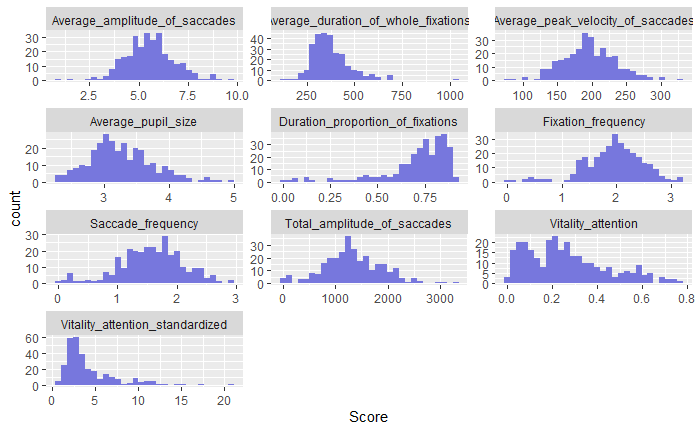

```r
# visualization: distribution
ggplot(for_descriptive_stat %>% gather(-(Key:`Level of Vitality`), key = 'Variable', value = 'Score')) +
  geom_histogram(aes(x = Score), fill = "#7777DD") +
  facet_wrap(~ Variable, ncol = 3, scales = "free")
```

> Reliability

Next, the reliability of the measurement tool should be validated. In the code below, Cronbach’s $\alpha$ coefficient of ITS and four subscale of PRS is computed.

```r
trait_trust %>% select(-Key) %>% psych::alpha()
```

```
Reliability analysis
Call: psych::alpha(x = .)
```

|  | raw_alpha | std.alpha | G6(smc) | average_r | S/N | ase | mean | sd | median_r |
| --- | --- | --- | --- | --- | --- | --- | --- | --- | --- |
|  | 0.650757 | 0.6710305 | 0.7093526 | 0.1694211 | 2.039796 | 0.0611136 | 2.465278 | 0.4108253 | 0.1578054 |

```
 lower alpha upper     95% confidence boundaries
0.53 0.65 0.77

 Reliability if an item is dropped:
```

|  | raw_alpha | std.alpha | G6(smc) | average_r | S/N | alpha se | var.r | med.r |
| --- | --- | --- | --- | --- | --- | --- | --- | --- |
| trust_1 | 0.5669000 | 0.5857357 | 0.6202778 | 0.1357719 | 1.413918 | 0.07617680 | 0.01486180 | 0.1239489 |
| trust_2 | 0.6213041 | 0.6390086 | 0.6663913 | 0.1643570 | 1.770149 | 0.06649123 | 0.01761665 | 0.1467612 |
| trust_3 | 0.6151480 | 0.6430325 | 0.6786269 | 0.1667728 | 1.801376 | 0.06825717 | 0.02042204 | 0.1528722 |
| trust_4 | 0.6459109 | 0.6697548 | 0.7014195 | 0.1838995 | 2.028053 | 0.06247365 | 0.01987012 | 0.1750658 |
| trust_5 | 0.6156120 | 0.6220538 | 0.6632973 | 0.1546024 | 1.645879 | 0.06759983 | 0.01758473 | 0.1467612 |
| trust_6 | 0.6480028 | 0.6689905 | 0.7055839 | 0.1833817 | 2.021061 | 0.06191996 | 0.02140445 | 0.1648545 |
| trust_7 | 0.6287530 | 0.6581233 | 0.6854931 | 0.1762037 | 1.925031 | 0.06566728 | 0.01963831 | 0.1732430 |
| trust_8 | 0.6496804 | 0.6689676 | 0.6981300 | 0.1833663 | 2.020853 | 0.06149441 | 0.01932348 | 0.1661938 |
| trust_9 | 0.6236658 | 0.6421649 | 0.6745425 | 0.1662485 | 1.794584 | 0.06592040 | 0.01864331 | 0.1467612 |
| trust_10 | 0.6409772 | 0.6633403 | 0.6980133 | 0.1796075 | 1.970359 | 0.06315204 | 0.02133072 | 0.1750658 |

```
 Item statistics
```

|  | n | raw.r | std.r | r.cor | r.drop | mean | sd |
| --- | --- | --- | --- | --- | --- | --- | --- |
| trust_1 | 72 | 0.7180802 | 0.7435548 | 0.7614114 | 0.6023202 | 2.361111 | 0.7926699 |
| trust_2 | 72 | 0.4957845 | 0.5387556 | 0.4874948 | 0.3473563 | 2.097222 | 0.7152213 |
| trust_3 | 72 | 0.5802781 | 0.5214472 | 0.4439725 | 0.3675788 | 2.666667 | 1.0614898 |
| trust_4 | 72 | 0.4622918 | 0.3987418 | 0.2783199 | 0.2402614 | 2.180556 | 0.9975518 |
| trust_5 | 72 | 0.5364716 | 0.6086424 | 0.5637219 | 0.4349889 | 1.791667 | 0.5290837 |
| trust_6 | 72 | 0.3857913 | 0.4024514 | 0.2693818 | 0.2026595 | 2.083333 | 0.8005280 |
| trust_7 | 72 | 0.4854047 | 0.4538786 | 0.3670718 | 0.3028134 | 3.430556 | 0.8529384 |
| trust_8 | 72 | 0.3922471 | 0.4025620 | 0.2912125 | 0.1995529 | 2.652778 | 0.8418578 |
| trust_9 | 72 | 0.4919363 | 0.5252032 | 0.4572114 | 0.3293970 | 2.277778 | 0.7731811 |
| trust_10 | 72 | 0.4427429 | 0.4294921 | 0.3121832 | 0.2467315 | 3.111111 | 0.8810294 |

```
Non missing response frequency for each item
            1    2    3    4    5 miss
trust_1  0.08 0.58 0.22 0.11 0.00    0
trust_2  0.15 0.65 0.14 0.06 0.00    0
trust_3  0.10 0.44 0.19 0.22 0.04    0
trust_4  0.28 0.40 0.18 0.14 0.00    0
trust_5  0.26 0.68 0.06 0.00 0.00    0
trust_6  0.19 0.60 0.15 0.04 0.01    0
trust_7  0.00 0.17 0.31 0.46 0.07    0
trust_8  0.03 0.49 0.31 0.17 0.01    0
trust_9  0.12 0.54 0.26 0.07 0.00    0
trust_10 0.03 0.22 0.39 0.33 0.03    0
```

```r
visit_scale %>% select(Escape1:Escape5) %>% psych::alpha()
```

```
Reliability analysis
Call: psych::alpha(x = .)
```

|  | raw_alpha | std.alpha | G6(smc) | average_r | S/N | ase | mean | sd | median_r |
| --- | --- | --- | --- | --- | --- | --- | --- | --- | --- |
|  | 0.953166 | 0.9535252 | 0.9434789 | 0.8040526 | 20.51705 | 0.004318204 | 3.816725 | 1.477855 | 0.7979402 |

```
 lower alpha upper     95% confidence boundaries
0.94 0.95 0.96

 Reliability if an item is dropped:
```

|  | raw_alpha | std.alpha | G6(smc) | average_r | S/N | alpha se | var.r | med.r |
| --- | --- | --- | --- | --- | --- | --- | --- | --- |
| Escape1 | 0.9451710 | 0.9454582 | 0.9295479 | 0.8125108 | 17.33456 | 0.005241918 | 0.0006294513 | 0.8152104 |
| Escape2 | 0.9420413 | 0.9424252 | 0.9254302 | 0.8036203 | 16.36870 | 0.005524688 | 0.0003203977 | 0.7979402 |
| Escape3 | 0.9451234 | 0.9456045 | 0.9295234 | 0.8129431 | 17.38387 | 0.005213849 | 0.0005512593 | 0.8132605 |
| Escape4 | 0.9390188 | 0.9397166 | 0.9221690 | 0.7957965 | 15.58830 | 0.005797452 | 0.0003500105 | 0.7936175 |
| Escape5 | 0.9390181 | 0.9395756 | 0.9223329 | 0.7953922 | 15.54960 | 0.005827318 | 0.0004287293 | 0.7920949 |

```
 Item statistics
```

|  | n | raw.r | std.r | r.cor | r.drop | mean | sd |
| --- | --- | --- | --- | --- | --- | --- | --- |
| Escape1 | 287 | 0.9040955 | 0.9072290 | 0.8733933 | 0.8534041 | 3.557491 | 1.510802 |
| Escape2 | 287 | 0.9214881 | 0.9188471 | 0.8937945 | 0.8720409 | 3.717770 | 1.695468 |
| Escape3 | 287 | 0.9047349 | 0.9066641 | 0.8727998 | 0.8523782 | 3.815331 | 1.554615 |
| Escape4 | 287 | 0.9293056 | 0.9290711 | 0.9096874 | 0.8879454 | 3.895470 | 1.598583 |
| Escape5 | 287 | 0.9315427 | 0.9295994 | 0.9100927 | 0.8883756 | 4.097561 | 1.684222 |

```
Non missing response frequency for each item
           1    2    3    4    5    6    7 miss
Escape1 0.08 0.20 0.22 0.21 0.18 0.08 0.02    0
Escape2 0.09 0.21 0.20 0.14 0.18 0.15 0.04    0
Escape3 0.06 0.17 0.23 0.19 0.20 0.13 0.03    0
Escape4 0.06 0.19 0.18 0.18 0.22 0.14 0.04    0
Escape5 0.07 0.14 0.19 0.11 0.26 0.17 0.06    0
```

```r
visit_scale %>% select(Fascination1:Fascination5) %>% psych::alpha()
```

```
Reliability analysis
Call: psych::alpha(x = .)
```

|  | raw_alpha | std.alpha | G6(smc) | average_r | S/N | ase | mean | sd | median_r |
| --- | --- | --- | --- | --- | --- | --- | --- | --- | --- |
|  | 0.9315923 | 0.9316615 | 0.9184833 | 0.7316596 | 13.63305 | 0.006355013 | 3.958188 | 1.435487 | 0.7253296 |

```
 lower alpha upper     95% confidence boundaries
0.92 0.93 0.94

 Reliability if an item is dropped:
```

|  | raw_alpha | std.alpha | G6(smc) | average_r | S/N | alpha se | var.r | med.r |
| --- | --- | --- | --- | --- | --- | --- | --- | --- |
| Fascination1 | 0.9174052 | 0.9175230 | 0.8970344 | 0.7355300 | 11.12459 | 0.007944430 | 0.0018817615 | 0.7253296 |
| Fascination2 | 0.9211284 | 0.9212028 | 0.9006434 | 0.7450737 | 11.69081 | 0.007555896 | 0.0017146640 | 0.7308064 |
| Fascination3 | 0.9114611 | 0.9117243 | 0.8864194 | 0.7208291 | 10.32814 | 0.008476505 | 0.0004112471 | 0.7162072 |
| Fascination4 | 0.9200562 | 0.9201828 | 0.8997368 | 0.7424111 | 11.52862 | 0.007678726 | 0.0018647332 | 0.7299174 |
| Fascination5 | 0.9090819 | 0.9091591 | 0.8828070 | 0.7144541 | 10.00825 | 0.008751193 | 0.0001689371 | 0.7077098 |

```
 Item statistics
```

|  | n | raw.r | std.r | r.cor | r.drop | mean | sd |
| --- | --- | --- | --- | --- | --- | --- | --- |
| Fascination1 | 287 | 0.8793682 | 0.8809462 | 0.8388969 | 0.8110130 | 4.038328 | 1.574023 |
| Fascination2 | 287 | 0.8681258 | 0.8680230 | 0.8179621 | 0.7910601 | 3.888502 | 1.624153 |
| Fascination3 | 287 | 0.9009383 | 0.9008529 | 0.8763142 | 0.8423305 | 3.742160 | 1.598644 |
| Fascination4 | 287 | 0.8700161 | 0.8716284 | 0.8235971 | 0.7965037 | 4.216028 | 1.582914 |
| Fascination5 | 287 | 0.9123615 | 0.9094854 | 0.8897293 | 0.8544304 | 3.905923 | 1.716294 |

```
Non missing response frequency for each item
                1    2    3    4    5    6    7 miss
Fascination1 0.05 0.16 0.19 0.17 0.24 0.16 0.04    0
Fascination2 0.05 0.19 0.23 0.16 0.17 0.15 0.05    0
Fascination3 0.08 0.17 0.22 0.17 0.21 0.10 0.04    0
Fascination4 0.04 0.12 0.20 0.17 0.24 0.17 0.06    0
Fascination5 0.07 0.17 0.22 0.15 0.17 0.14 0.07    0
```

```r
visit_scale %>% select(Coherence1:Coherence4) %>% psych::alpha()
```

```
Reliability analysis
Call: psych::alpha(x = .)
```

|  | raw_alpha | std.alpha | G6(smc) | average_r | S/N | ase | mean | sd | median_r |
| --- | --- | --- | --- | --- | --- | --- | --- | --- | --- |
|  | 0.7120384 | 0.7107906 | 0.6874027 | 0.3805847 | 2.457703 | 0.02765477 | 4.085366 | 1.107284 | 0.4259031 |

```
 lower alpha upper     95% confidence boundaries
0.66 0.71 0.77

 Reliability if an item is dropped:
```

|  | raw_alpha | std.alpha | G6(smc) | average_r | S/N | alpha se | var.r | med.r |
| --- | --- | --- | --- | --- | --- | --- | --- | --- |
| Coherence1 | 0.5428360 | 0.5373350 | 0.4747693 | 0.2790873 | 1.161391 | 0.04633701 | 0.030052179 | 0.2866028 |
| Coherence2 | 0.7034096 | 0.7048362 | 0.6443757 | 0.4432019 | 2.387949 | 0.03058355 | 0.022509638 | 0.4573361 |
| Coherence3 | 0.7344740 | 0.7340355 | 0.6588697 | 0.4791577 | 2.759900 | 0.02703584 | 0.009021596 | 0.4485629 |
| Coherence4 | 0.5855304 | 0.5863596 | 0.5383167 | 0.3208919 | 1.417559 | 0.04280606 | 0.036635207 | 0.4032434 |

```
 Item statistics
```

|  | n | raw.r | std.r | r.cor | r.drop | mean | sd |
| --- | --- | --- | --- | --- | --- | --- | --- |
| Coherence1 | 287 | 0.8324061 | 0.8357673 | 0.7863798 | 0.6702720 | 4.000000 | 1.469979 |
| Coherence2 | 287 | 0.6675849 | 0.6675566 | 0.4924569 | 0.4058697 | 3.989547 | 1.492368 |
| Coherence3 | 287 | 0.6225743 | 0.6307034 | 0.4392296 | 0.3477553 | 4.379791 | 1.471884 |
| Coherence4 | 287 | 0.8038780 | 0.7929193 | 0.7086579 | 0.5953770 | 3.972125 | 1.608301 |

```
Non missing response frequency for each item
              1    2    3    4    5    6    7 miss
Coherence1 0.02 0.14 0.26 0.22 0.20 0.11 0.06    0
Coherence2 0.03 0.16 0.22 0.20 0.19 0.17 0.02    0
Coherence3 0.02 0.10 0.16 0.20 0.26 0.21 0.05    0
Coherence4 0.05 0.15 0.21 0.21 0.17 0.14 0.06    0
```

```r
visit_scale %>% select(Compatibility1:Compatibility5) %>% psych::alpha()
```

```
Reliability analysis
Call: psych::alpha(x = .)
```

|  | raw_alpha | std.alpha | G6(smc) | average_r | S/N | ase | mean | sd | median_r |
| --- | --- | --- | --- | --- | --- | --- | --- | --- | --- |
|  | 0.8509814 | 0.8514239 | 0.830846 | 0.534041 | 5.730558 | 0.0139219 | 3.296864 | 1.118796 | 0.5316334 |

```
 lower alpha upper     95% confidence boundaries
0.82 0.85 0.88

 Reliability if an item is dropped:
```

|  | raw_alpha | std.alpha | G6(smc) | average_r | S/N | alpha se | var.r | med.r |
| --- | --- | --- | --- | --- | --- | --- | --- | --- |
| Compatibility1 | 0.8283234 | 0.8289787 | 0.7950244 | 0.5478808 | 4.847224 | 0.01658370 | 0.004022062 | 0.5339724 |
| Compatibility2 | 0.8231848 | 0.8229653 | 0.7802091 | 0.5374979 | 4.648610 | 0.01697656 | 0.002723672 | 0.5370834 |
| Compatibility3 | 0.8194468 | 0.8191737 | 0.7764965 | 0.5310762 | 4.530170 | 0.01727063 | 0.002448024 | 0.5216372 |
| Compatibility4 | 0.8159164 | 0.8172425 | 0.7828638 | 0.5278415 | 4.471731 | 0.01781562 | 0.004331970 | 0.5239762 |
| Compatibility5 | 0.8148546 | 0.8160816 | 0.7781054 | 0.5259087 | 4.437194 | 0.01792820 | 0.003730131 | 0.5185262 |

```
 Item statistics
```

|  | n | raw.r | std.r | r.cor | r.drop | mean | sd |
| --- | --- | --- | --- | --- | --- | --- | --- |
| Compatibility1 | 287 | 0.7751822 | 0.7710104 | 0.6844443 | 0.6323996 | 3.432056 | 1.451338 |
| Compatibility2 | 287 | 0.7774537 | 0.7867425 | 0.7179196 | 0.6524309 | 2.905923 | 1.320177 |
| Compatibility3 | 287 | 0.7920450 | 0.7964726 | 0.7333138 | 0.6652978 | 3.170732 | 1.387550 |
| Compatibility4 | 287 | 0.8033578 | 0.8013738 | 0.7330884 | 0.6783011 | 3.355401 | 1.418841 |
| Compatibility5 | 287 | 0.8112824 | 0.8043023 | 0.7407139 | 0.6825659 | 3.620209 | 1.483714 |

```
Non missing response frequency for each item
                  1    2    3    4    5    6    7 miss
Compatibility1 0.07 0.22 0.29 0.16 0.15 0.10 0.01    0
Compatibility2 0.13 0.30 0.30 0.15 0.09 0.03 0.01    0
Compatibility3 0.10 0.25 0.30 0.16 0.14 0.05 0.01    0
Compatibility4 0.08 0.21 0.31 0.19 0.13 0.08 0.01    0
Compatibility5 0.06 0.22 0.22 0.20 0.19 0.10 0.02    0
```

```r
vital_subjective %>% psych::alpha()
```

```
Reliability analysis
Call: psych::alpha(x = .)
```

|  | raw_alpha | std.alpha | G6(smc) | average_r | S/N | ase | mean | sd | median_r |
| --- | --- | --- | --- | --- | --- | --- | --- | --- | --- |
|  | 0.9166507 | 0.9189248 | 0.9179498 | 0.6182006 | 11.33423 | 0.01051342 | 5.110119 | 0.9363531 | 0.6124024 |

```
 lower alpha upper     95% confidence boundaries
0.9 0.92 0.94

 Reliability if an item is dropped:
```

|  | raw_alpha | std.alpha | G6(smc) | average_r | S/N | alpha se | var.r | med.r |
| --- | --- | --- | --- | --- | --- | --- | --- | --- |
| vital_1 | 0.9004908 | 0.9027511 | 0.8966239 | 0.6074041 | 9.282889 | 0.01268852 | 0.009450644 | 0.5937790 |
| vital_2 | 0.8962995 | 0.8978290 | 0.8873974 | 0.5942522 | 8.787512 | 0.01316723 | 0.007070252 | 0.5937790 |
| vital_3 | 0.9051191 | 0.9078752 | 0.9053328 | 0.6215668 | 9.854844 | 0.01215309 | 0.011333420 | 0.5937790 |
| vital_4 | 0.9061681 | 0.9075629 | 0.9046337 | 0.6206892 | 9.818162 | 0.01213309 | 0.010959454 | 0.5937790 |
| vital_5 | 0.9174123 | 0.9210441 | 0.9180580 | 0.6603510 | 11.665298 | 0.01067990 | 0.006622945 | 0.6519432 |
| vital_6 | 0.8916422 | 0.8954800 | 0.8871382 | 0.5881256 | 8.567547 | 0.01390630 | 0.009111877 | 0.5773041 |
| vital_7 | 0.9102387 | 0.9125801 | 0.9086486 | 0.6350151 | 10.439037 | 0.01145888 | 0.011092582 | 0.6394419 |

```
 Item statistics
```

|  | n | raw.r | std.r | r.cor | r.drop | mean | sd |
| --- | --- | --- | --- | --- | --- | --- | --- |
| vital_1 | 144 | 0.8420022 | 0.8484159 | 0.8295092 | 0.7835387 | 5.347222 | 1.059882 |
| vital_2 | 144 | 0.8757875 | 0.8827761 | 0.8802147 | 0.8296189 | 5.395833 | 1.039222 |
| vital_3 | 144 | 0.8055853 | 0.8114149 | 0.7695972 | 0.7350747 | 5.326389 | 1.069801 |
| vital_4 | 144 | 0.8258628 | 0.8137077 | 0.7741019 | 0.7400903 | 5.083333 | 1.345804 |
| vital_5 | 144 | 0.7045866 | 0.7100881 | 0.6293665 | 0.6059650 | 5.819444 | 1.075166 |
| vital_6 | 144 | 0.9017977 | 0.8987825 | 0.8941905 | 0.8586930 | 5.166667 | 1.164750 |
| vital_7 | 144 | 0.7835301 | 0.7762801 | 0.7239005 | 0.6913277 | 3.631944 | 1.238917 |

```
Non missing response frequency for each item
           1    2    3    4    5    6    7 miss
vital_1 0.00 0.02 0.04 0.10 0.35 0.40 0.10    0
vital_2 0.00 0.01 0.05 0.09 0.32 0.43 0.10    0
vital_3 0.00 0.01 0.06 0.14 0.27 0.43 0.09    0
vital_4 0.00 0.04 0.14 0.10 0.24 0.39 0.10    0
vital_5 0.00 0.01 0.03 0.08 0.19 0.40 0.29    0
vital_6 0.00 0.03 0.05 0.19 0.31 0.33 0.10    0
vital_7 0.03 0.14 0.28 0.35 0.13 0.05 0.02    0
```

> Validity